# Analyzing Twitter Sentiment and its Impact on Tesla Stock

### Motivation:

Sentiment analysis has become an increasingly important tool in understanding public opinion and its impact on various domains. Social media platforms like Twitter serve as a treasure trove of real-time data, reflecting the sentiments and emotions of millions of users.

### Objective:

This project aims to leverage the power of sentiment analysis on Twitter data to uncover valuable insights and explore its impact on stock price of TSLA.

### Brief Outline of the Project:

1. Download Pre-existing Twitter data from Kaggle
2. Explore and select the data I want to do sentiment analysis on.
3. Clean and Preprocess the data.
4. Perform Sentiment Analysis using TextBlob and Calculate Polartity Score
5. Get Tesla Stock Price data for the same period using Yfinance API.
6. Performing EDA on Stock Data and any Data Cleaning steps if needed.
7. Merge both the datasets
8. Perform Correlation Analysis to identify any impact of public sentiment on stock price.
9. Summarize the findings
10. Discuss limitations of the project and future work.

#### Let's get started!

```python
# Importing the necessary libraries
import re
import pandas as pd
import matplotlib.pyplot as plt
import seaborn as sns
%matplotlib inline
sns.set()

import yfinance as yf
from textblob import TextBlob
from nltk.corpus import stopwords
from nltk.tokenize import word_tokenize
from nltk.stem import WordNetLemmatizer
```

### Twitter Data Retrieval

```python
#All below datasets downloaded locally from kaggle
#tweet= "https://www.kaggle.com/datasets/omermetinn/tweets-about-the-top-companies-from-2015-to-2020?select=Tweet.csv"
#company= "https://www.kaggle.com/datasets/omermetinn/tweets-about-the-top-companies-from-2015-to-2020?select=Company.csv"
#company_tweet = "https://www.kaggle.com/datasets/omermetinn/tweets-about-the-top-companies-from-2015-to-2020?select=Company_Tweet.csv"

company_df = pd.read_csv("Company.csv")
tweet_df = pd.read_csv("Tweet.csv")
company_tweet_df = pd.read_csv("Company_Tweet.csv")
```

```python
#Taking a look at company.csv data
company_df
```

|  | ticker_symbol | company_name |
| --- | --- | --- |
| 0 | AAPL | apple |
| 1 | GOOG | Google Inc |
| 2 | GOOGL | Google Inc |
| 3 | AMZN | Amazon.com |
| 4 | TSLA | Tesla Inc |
| 5 | MSFT | Microsoft |

### Data Selection

The Company.csv has 6 ticker symbols. For this project I'll focus on $TSLA for tweet sentiment analysis and stock market correlation analysis.

```python
#Saving the TSLA ticker symbol to "tsla" variable
tsla = company_df.ticker_symbol[4]
tsla
```

```
'TSLA'
```

```python
#Taking a look at Tweet.csv data
tweet_df.head()
```

|  | tweet_id | writer | post_date | body | comment_num | retweet_num | like_num |
| --- | --- | --- | --- | --- | --- | --- | --- |
| 0 | 550441509175443456 | VisualStockRSRC | 1420070457 | lx21 made $10,008 on $AAPL -Check it out! htt... | 0 | 0 | 1 |
| 1 | 550441672312512512 | KeralaGuy77 | 1420070496 | Insanity of today weirdo massive selling. $aap... | 0 | 0 | 0 |
| 2 | 550441732014223360 | DozenStocks | 1420070510 | S&P100 #Stocks Performance $HD $LOW $SBUX $TGT... | 0 | 0 | 0 |
| 3 | 550442977802207232 | ShowDreamCar | 1420070807 | $GM $TSLA: Volkswagen Pushes 2014 Record Recal... | 0 | 0 | 1 |
| 4 | 550443807834402816 | i_Know_First | 1420071005 | Swing Trading: Up To 8.91% Return In 14 Days h... | 0 | 0 | 1 |

The Tweet.csv data has the tweets data including tweet id, write, posted date, no. of comments, no. of retweets and likes.

```python
#Taking a look at Company_Tweet.csv data
company_tweet_df.head()
```

|  | tweet_id | ticker_symbol |
| --- | --- | --- |
| 0 | 550803612197457920 | AAPL |
| 1 | 550803610825928706 | AAPL |
| 2 | 550803225113157632 | AAPL |
| 3 | 550802957370159104 | AAPL |
| 4 | 550802855129382912 | AAPL |

The Company_Tweet.csv file has data for tweet_id and the Stock it is related to. I'll use this data to extract tweet ids for TSLA ticker symbol.

```python
#Getting tweet ids for tweets related to TSLA from company_tweet_df
tsla_tweets_ids = company_tweet_df[company_tweet_df.ticker_symbol==tsla].tweet_id
```

```python
#Filtering the tweet_df to get TSLA tweets using TSLA Tweet ids extracted above
tsla_tweets = tweet_df[tweet_df.tweet_id.isin(tsla_tweets_ids)].reset_index(drop=True)
```

```python
#Converting post_date column in seconds to datetime64[ns]

tsla_tweets['post_date_datetime'] = pd.to_datetime(tsla_tweets['post_date'], unit='s')
tsla_tweets.head()
```

|  | tweet_id | writer | post_date | body | comment_num | retweet_num | like_num | post_date_datetime |
| --- | --- | --- | --- | --- | --- | --- | --- | --- |
| 0 | 550442977802207232 | ShowDreamCar | 1420070807 | $GM $TSLA: Volkswagen Pushes 2014 Record Recal... | 0 | 0 | 1 | 2015-01-01 00:06:47 |
| 1 | 550443807834402816 | i_Know_First | 1420071005 | Swing Trading: Up To 8.91% Return In 14 Days h... | 0 | 0 | 1 | 2015-01-01 00:10:05 |
| 2 | 550443808606126081 | aaplstocknews | 1420071005 | Swing Trading: Up To 8.91% Return In 14 Days h... | 0 | 0 | 1 | 2015-01-01 00:10:05 |
| 3 | 550443809700851716 | iknowfirst | 1420071005 | Swing Trading: Up To 8.91% Return In 14 Days h... | 0 | 0 | 1 | 2015-01-01 00:10:05 |
| 4 | 550443857142611968 | Cprediction | 1420071016 | Swing Trading: Up To 8.91% Return In 14 Days h... | 0 | 0 | 1 | 2015-01-01 00:10:16 |

```python
tsla_tweets.info()
```

```
<class 'pandas.core.frame.DataFrame'>
RangeIndex: 1096868 entries, 0 to 1096867
Data columns (total 8 columns):
 #   Column              Non-Null Count    Dtype
---  ------              --------------    -----
 0   tweet_id            1096868 non-null  int64
 1   writer              1073202 non-null  object
 2   post_date           1096868 non-null  int64
 3   body                1096868 non-null  object
 4   comment_num         1096868 non-null  int64
 5   retweet_num         1096868 non-null  int64
 6   like_num            1096868 non-null  int64
 7   post_date_datetime  1096868 non-null  datetime64[ns]
dtypes: datetime64[ns](1), int64(5), object(2)
memory usage: 66.9+ MB
```

For this project, I'll do sentiment analysis on tweet data for year 2019.

```python
#Getting tweet data for year 2019 to do sentiment analysis

tsla_tweets2019 = tsla_tweets[tsla_tweets['post_date_datetime']>pd.to_datetime('2019-01-01 00:00:00')].reset_index(drop=True)
```

```python
#tsla_tweets2019.to_csv('tsla_tweets2019.csv', index=False)
```

```python
tsla_tweets2019['Date'] = tsla_tweets2019['post_date_datetime'].dt.date
tsla_tweets2019.head()
```

|  | tweet_id | writer | post_date | body | comment_num | retweet_num | like_num | post_date_datetime | Date |
| --- | --- | --- | --- | --- | --- | --- | --- | --- | --- |
| 0 | 1079890068867817473 | evdefender | 1546300830 | !! 8 Hours Left !!The picture you see here is... | 6 | 16 | 82 | 2019-01-01 00:00:30 | 2019-01-01 |
| 1 | 1079890718326431745 | O__rust | 1546300985 | $3750 would be the minimum discount in any cas... | 0 | 0 | 0 | 2019-01-01 00:03:05 | 2019-01-01 |
| 2 | 1079890782742503424 | GunGermSteel | 1546301000 | There are FUDking analysts like those from gol... | 0 | 0 | 1 | 2019-01-01 00:03:20 | 2019-01-01 |
| 3 | 1079891097965322240 | ruskitrader | 1546301075 | I really hope they report ‘unbelievable’ numbe... | 0 | 0 | 3 | 2019-01-01 00:04:35 | 2019-01-01 |
| 4 | 1079891844807430144 | Path_Trading | 1546301253 | #TESLA : $TSLA Dec-31 Update #StockMarket #Tec... | 0 | 0 | 0 | 2019-01-01 00:07:33 | 2019-01-01 |

```python
tsla_tweets2019.shape
```

```
(380115, 9)
```

```python
tsla_tweets2019.duplicated().sum()
```

```
0
```

### Data Cleaning

```python
#Now the data is ready. Moving on to cleaning and preprocessing steps

#Function to clean the tweet
def clean_tweet(tweet):
    # Remove URLs
    tweet = re.sub(r'http\S+|www\S+|https\S+', '', tweet, flags=re.MULTILINE)
    # Remove mentions (@username)
    tweet = re.sub(r'@\w+', '', tweet)
    # Remove hashtags
    tweet = re.sub(r'#\w+', '', tweet)
    # Remove special characters and numbers
    tweet = re.sub(r'\W', ' ', tweet)
    tweet = re.sub(r'\s+[a-zA-Z]\s+', ' ', tweet)
    tweet = re.sub(r'\^[a-zA-Z]\s+', ' ', tweet)
    tweet = re.sub(r'\s+', ' ', tweet, flags=re.I)
    # Convert to lowercase
    tweet = tweet.lower()
    # Remove any leading or trailing white spaces
    tweet = tweet.strip()

    return tweet
```

```python
# Initializing the lemmatizer and stopwords
lemmatizer = WordNetLemmatizer()
stop_words = set(stopwords.words('english'))

def preprocess_tweet(tweet):
    #clean the tweet using clean_tweet() function
    cleaned_tweet = clean_tweet(tweet)

    #Tokenization
    tokens = word_tokenize(cleaned_tweet)

    # Stopword removal
    tokens = [word for word in tokens if word not in stop_words]

    # Lemmatization
    tokens = [lemmatizer.lemmatize(word) for word in tokens]
    return ' '.join(tokens)
```

```python
# Function to get the polarity of a tweet
def get_polarity(tweet):
    return TextBlob(tweet).sentiment.polarity
```

```python
#Function to label the tweet according to the polarity score

def label_sentiment(polarity):
    if polarity == 0:
        return "neutral"
    elif 0 < polarity <= 0.3:
        return "weak positive"
    elif 0.3 < polarity <= 0.6:
        return "positive"
    elif 0.6 < polarity <= 1:
        return "strong positive"
    elif 0 > polarity > -0.3:
        return "weak negative"
    elif -0.3 >= polarity > -0.6:
        return "negative"
    elif -0.6 >= polarity >= -1:
        return "strong negative"
```

```python
#getting the relevant columns and creating a new dataframe
tsla_2019 = tsla_tweets2019[['Date', 'body']].rename(columns={'body': 'Tweet'})
tsla_2019.head()
```

|  | Date | Tweet |
| --- | --- | --- |
| 0 | 2019-01-01 | !! 8 Hours Left !!The picture you see here is... |
| 1 | 2019-01-01 | $3750 would be the minimum discount in any cas... |
| 2 | 2019-01-01 | There are FUDking analysts like those from gol... |
| 3 | 2019-01-01 | I really hope they report ‘unbelievable’ numbe... |
| 4 | 2019-01-01 | #TESLA : $TSLA Dec-31 Update #StockMarket #Tec... |

```python
tsla_2019.isnull().sum()
```

```
Date     0
Tweet    0
dtype: int64
```

```python
#Applying cleaning and preprocessing steps

tsla_2019['Preprocessed Tweet'] = tsla_2019['Tweet'].apply(preprocess_tweet)
tsla_2019.head()
```

|  | Date | Tweet | Preprocessed Tweet |
| --- | --- | --- | --- |
| 0 | 2019-01-01 | !! 8 Hours Left !!The picture you see here is... | 8 hour left picture see man violating federal ... |
| 1 | 2019-01-01 | $3750 would be the minimum discount in any cas... | 3750 would minimum discount case probably 5k p... |
| 2 | 2019-01-01 | There are FUDking analysts like those from gol... | fudking analyst like goldmansuck jpm analyst w... |
| 3 | 2019-01-01 | I really hope they report ‘unbelievable’ numbe... | really hope report unbelievable number like go... |
| 4 | 2019-01-01 | #TESLA : $TSLA Dec-31 Update #StockMarket #Tec... | tsla dec 31 update |

```python
#calculating the polarity score using TextBlob

tsla_2019['Polarity Score'] = tsla_2019['Preprocessed Tweet'].apply(get_polarity)
tsla_2019.head()
```

|  | Date | Tweet | Preprocessed Tweet | Polarity Score |
| --- | --- | --- | --- | --- |
| 0 | 2019-01-01 | !! 8 Hours Left !!The picture you see here is... | 8 hour left picture see man violating federal ... | -0.0300 |
| 1 | 2019-01-01 | $3750 would be the minimum discount in any cas... | 3750 would minimum discount case probably 5k p... | 0.1000 |
| 2 | 2019-01-01 | There are FUDking analysts like those from gol... | fudking analyst like goldmansuck jpm analyst w... | 0.0000 |
| 3 | 2019-01-01 | I really hope they report ‘unbelievable’ numbe... | really hope report unbelievable number like go... | -0.1525 |
| 4 | 2019-01-01 | #TESLA : $TSLA Dec-31 Update #StockMarket #Tec... | tsla dec 31 update | 0.0000 |

```python
#Labelling the sentiment based on polarity score

tsla_2019['Sentiment Label'] = tsla_2019['Polarity Score'].apply(label_sentiment)
tsla_2019.head()
```

|  | Date | Tweet | Preprocessed Tweet | Polarity Score | Sentiment Label |
| --- | --- | --- | --- | --- | --- |
| 0 | 2019-01-01 | !! 8 Hours Left !!The picture you see here is... | 8 hour left picture see man violating federal ... | -0.0300 | weak negative |
| 1 | 2019-01-01 | $3750 would be the minimum discount in any cas... | 3750 would minimum discount case probably 5k p... | 0.1000 | weak positive |
| 2 | 2019-01-01 | There are FUDking analysts like those from gol... | fudking analyst like goldmansuck jpm analyst w... | 0.0000 | neutral |
| 3 | 2019-01-01 | I really hope they report ‘unbelievable’ numbe... | really hope report unbelievable number like go... | -0.1525 | weak negative |
| 4 | 2019-01-01 | #TESLA : $TSLA Dec-31 Update #StockMarket #Tec... | tsla dec 31 update | 0.0000 | neutral |

```python
tsla_2019['Sentiment Label'].value_counts(normalize=True) * 100
```

```
neutral            36.586033
weak positive      28.599766
weak negative      14.449574
positive           11.683306
negative            4.070347
strong positive     3.251384
strong negative     1.359589
Name: Sentiment Label, dtype: float64
```

```python
#Creating a new datframe using groupby function to get average polarity score each day
avg_score_df = tsla_2019.groupby(['Date'])['Polarity Score'].mean().to_frame(name='Avg Score')
avg_score_df.index = pd.to_datetime(avg_score_df.index)
avg_score_df.head()
```

| Date | Avg Score |
| --- | --- |
| 2019-01-01 | 0.089673 |
| 2019-01-02 | 0.090595 |
| 2019-01-03 | 0.071648 |
| 2019-01-04 | 0.077351 |
| 2019-01-05 | 0.085345 |

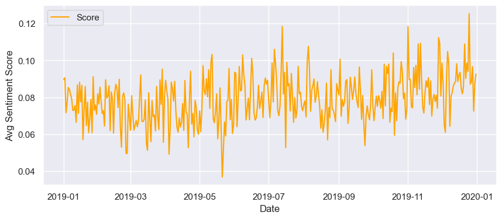

```python
#Plotting a line chart to see the avg sentiment score throughout the year
plt.figure(figsize=(10,4))
plt.plot(avg_score_df.index, avg_score_df['Avg Score'], color='orange', label='Score')
plt.xlabel("Date")
plt.ylabel("Avg Sentiment Score")
plt.legend()
plt.show()
```

#### Retrieving Tesla Stock Data Using Yfinance API for 2019

```python
# Define the date range
start_date = '2019-01-01'
end_date = '2019-12-31'

# Fetch Tesla's stock price data directly and save in the data frame
tesla_data = yf.download('TSLA', start=start_date, end=end_date)

# Print the dataframe
print(tesla_data)
```

```
[*********************100%***********************]  1 of 1 completed
                 Open       High        Low      Close  Adj Close     Volume
Date
2019-01-02  20.406668  21.008667  19.920000  20.674667  20.674667  174879000
2019-01-03  20.466667  20.626667  19.825333  20.024000  20.024000  104478000
2019-01-04  20.400000  21.200001  20.181999  21.179333  21.179333  110911500
2019-01-07  21.448000  22.449333  21.183332  22.330667  22.330667  113268000
2019-01-08  22.797333  22.934000  21.801332  22.356667  22.356667  105127500
...               ...        ...        ...        ...        ...        ...
2019-12-23  27.452000  28.134001  27.333332  27.948000  27.948000  199794000
2019-12-24  27.890667  28.364668  27.512667  28.350000  28.350000  120820500
2019-12-26  28.527332  28.898666  28.423332  28.729334  28.729334  159508500
2019-12-27  29.000000  29.020666  28.407333  28.691999  28.691999  149185500
2019-12-30  28.586000  28.600000  27.284000  27.646667  27.646667  188796000

[251 rows x 6 columns]
```

#### EDA on Stock Data

```python
tesla_data.info()
```

```
<class 'pandas.core.frame.DataFrame'>
DatetimeIndex: 251 entries, 2019-01-02 to 2019-12-30
Data columns (total 6 columns):
 #   Column     Non-Null Count  Dtype
---  ------     --------------  -----
 0   Open       251 non-null    float64
 1   High       251 non-null    float64
 2   Low        251 non-null    float64
 3   Close      251 non-null    float64
 4   Adj Close  251 non-null    float64
 5   Volume     251 non-null    int64
dtypes: float64(5), int64(1)
memory usage: 13.7 KB
```

```python
tesla_data.describe()
```

|  | Open | High | Low | Close | Adj Close | Volume |
| --- | --- | --- | --- | --- | --- | --- |
| count | 251.000000 | 251.000000 | 251.000000 | 251.000000 | 251.000000 | 2.510000e+02 |
| mean | 18.166823 | 18.471835 | 17.872053 | 18.196887 | 18.196887 | 1.373165e+08 |
| std | 3.451933 | 3.501542 | 3.431770 | 3.489193 | 3.489193 | 7.160530e+07 |
| min | 12.073333 | 12.445333 | 11.799333 | 11.931333 | 11.931333 | 3.698400e+07 |
| 25% | 15.415000 | 15.650667 | 15.165000 | 15.475333 | 15.475333 | 9.084750e+07 |
| 50% | 17.313999 | 17.545334 | 17.049999 | 17.344667 | 17.344667 | 1.158720e+08 |
| 75% | 20.464667 | 21.046667 | 20.191000 | 20.731000 | 20.731000 | 1.600372e+08 |
| max | 29.000000 | 29.020666 | 28.423332 | 28.729334 | 28.729334 | 4.500915e+08 |

In 2019, the max stock price of TSLA was 29.02 and min was 11.8. The max trading in one day was 450M trades.

```python
#Checking for missing values
tesla_data.isnull().sum()
```

```
Open         0
High         0
Low          0
Close        0
Adj Close    0
Volume       0
dtype: int64
```

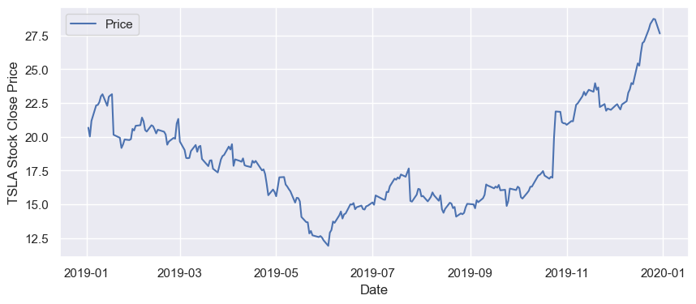

```python
#Plotting a line chart to see the Stock Price Trend
plt.figure(figsize=(10,4))
plt.plot(tesla_data.index, tesla_data['Close'], label='Price')
plt.xlabel("Date")
plt.ylabel("TSLA Stock Close Price")
plt.legend()
plt.show()
```

No missing values. Moving on to merging the tesla stock price data with tweet sentiment score

```python
#Merging the data
merged_data = tesla_data.merge(avg_score_df, left_index=True, right_index=True)
merged_data.head()
```

| Date | Open | High | Low | Close | Adj Close | Volume | Avg Score |
| --- | --- | --- | --- | --- | --- | --- | --- |
| 2019-01-02 | 20.406668 | 21.008667 | 19.920000 | 20.674667 | 20.674667 | 174879000 | 0.090595 |
| 2019-01-03 | 20.466667 | 20.626667 | 19.825333 | 20.024000 | 20.024000 | 104478000 | 0.071648 |
| 2019-01-04 | 20.400000 | 21.200001 | 20.181999 | 21.179333 | 21.179333 | 110911500 | 0.077351 |
| 2019-01-07 | 21.448000 | 22.449333 | 21.183332 | 22.330667 | 22.330667 | 113268000 | 0.081598 |
| 2019-01-08 | 22.797333 | 22.934000 | 21.801332 | 22.356667 | 22.356667 | 105127500 | 0.079299 |

```python
# Applying Manual Min-Max Scaling to [0, 1] range for plotting
merged_data['Scaled_Close'] = (merged_data['Close'] - merged_data['Close'].min()) / (merged_data['Close'].max() - merged_data['Close'].min())
merged_data['Scaled_Score'] = (merged_data['Avg Score'] - merged_data['Avg Score'].min()) / (merged_data['Avg Score'].max() - merged_data['Avg Score'].min())
```

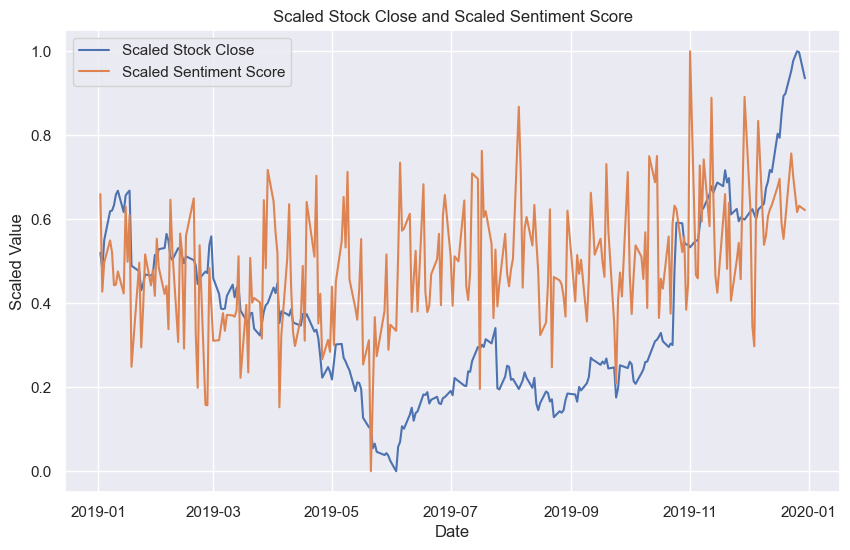

```python
# Plot the scaled data
plt.figure(figsize=(10, 6))
plt.plot(merged_data.index, merged_data['Scaled_Close'], label='Scaled Stock Close')
plt.plot(merged_data.index, merged_data['Scaled_Score'], label='Scaled Sentiment Score')
plt.title("Scaled Stock Close and Scaled Sentiment Score")
plt.xlabel("Date")
plt.ylabel("Scaled Value")
plt.legend()
plt.show()
```

From the visualization, we can observe some correlation between sentiment scores and stock prices, but it's not very clear-cut. There are periods where both the sentiment and stock price move in tandem, while at other times they diverge. To quantify the relationship, let's calculate the correlation coefficient between the average sentiment score and the stock's closing price.

```python
#Calculating the correlation score between Avg Sentiment Score and Stock Closing Price
correlation = merged_data['Avg Score'].corr(merged_data['Close'])
correlation
```

```
0.2800317939634678
```

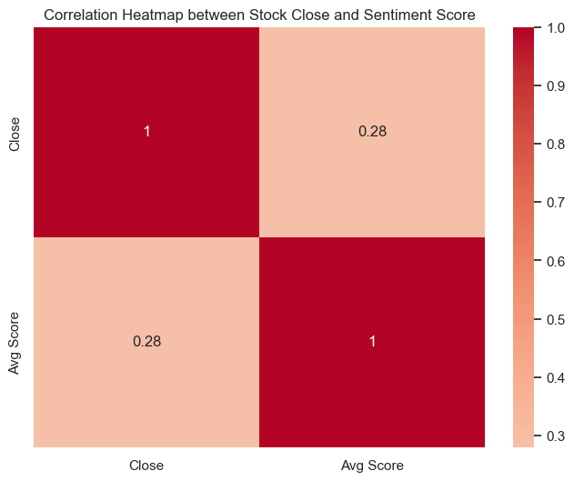

```python
# Calculate correlation using pandas corr() function
correlation_matrix = merged_data[['Close', 'Avg Score']].corr()

# Create a heatmap using seaborn
plt.figure(figsize=(8, 6))
sns.heatmap(correlation_matrix, annot=True, cmap='coolwarm', center=0)
plt.title("Correlation Heatmap between Stock Close and Sentiment Score")
plt.show()
```

From above correlation matrix it is evident that there is a positive(weak) correlation between stock price data and sentiment score. Meaning, there's a slight tendency for the stock price to rise on days when the average sentiment of tweets related to "TSLA" is more positive, and vice versa. However, the correlation is not strong, and other factors likely play a significant role in influencing the stock price.

**Insights**:

**Conclusion**:

- A significant portion of tweets related to "TSLA" in 2019 were **neutral**. This might suggest that many discussions about TSLA on Twitter during this period were factual or lacked strong emotional sentiment.
- Positive sentiments (combining weak positive, positive, and strong positive) were more prevalent than negative sentiments, indicating a generally favorable view or optimism about TSLA among Twitter users in 2019.
- Relying solely on tweet sentiment to predict stock price movements would be risky due to the weak correlation observed.

**Limitations**:

- I used daily averages for sentiment scores, which might mask intraday variations in sentiment. Real-time stock price movements might be influenced by intraday tweet sentiment spikes.
- The analysis relied solely on Twitter data. This excludes sentiments and discussions from other significant platforms, forums, or news outlets.
- The analysis did not account for external events (e.g., company announcements, global events, industry trends) that could have significant impacts on stock prices.
- I assumed the provided dataset from kaggle covered all relevant tweets for 2019, but I didn't validate the completeness of the data.

**Future Work**:

- Employ advanced sentiment analysis techniques, possibly using deep learning models, to capture nuanced sentiments more accurately.
- Integrate sentiments from other platforms like financial news websites, forums, and other social media platforms for a more comprehensive sentiment overview.